# Module 100

#### Hemi-module gene counts:

352 probesets in hemi-module A.  
50 probesets in hemi-module B.  
Note: While the mapping of probesets to genes is usually one-to-one, some genes are targeted by multiple probesets, some probesets target multiple genes, and some probesets do not target any genes (i.e., the region of the genome they match is no longer considered genic).

#### Contrast SVE:

Signed variance explained (SVE) provides an indication of how similar a set of fold changes are to a gene module’s weight vector. An SVE value of 0.3, for example, indicates that 30% of the variance explained by the entire module set is accounted for by the module in question. Shown here are the SVE values for this module across a compendium of fold changes (contrasts). Extreme SVE values (e.g., > 0.05) indicate that those contrasts specifically induce (orange dots) or specifically repress (blue dots) this module. Examining the experimental conditions being compared in such contrasts (see tables below the figure) may provide insight into the gene module’s function.

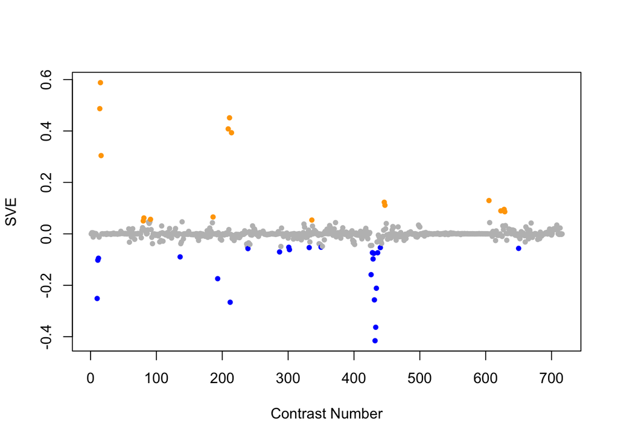

Positive SVE Contrasts:

|  | Contrast.Num | SVE | GEO.GSE | Cond.1 | Cond.2 | Mutation |
| --- | --- | --- | --- | --- | --- | --- |
| GSE9682.s2t2.vs.s2t1 | 15 | 0.59 | GSE9682 | N2-Cel-TORRNAi-fed-biological rep1 | N2-Cel-TORRNAi-fasting-biological rep1 |  |
| GSE9682.s1t2.vs.s1t1 | 14 | 0.49 | GSE9682 | N2-Cel-RhebRNAi-fed-biological rep1 | N2-Cel-RhebRNAi-fasting-biological rep1 |  |
| GSE42689.s4t1.vs.s1t1 | 211 | 0.45 | GSE42689 | mlk-1 fed 1 | mek-1 fasted 1 |  |
| GSE42689.s2t1.vs.s1t1 | 209 | 0.41 | GSE42689 | mek-1 fed 1 | mek-1 fasted 1 |  |
| GSE42689.s4t1.vs.s3t1 | 214 | 0.39 | GSE42689 | mlk-1 fed 1 | mlk-1 fasted 1 |  |
| GSE9682.s0t2.vs.s0t1 | 16 | 0.30 | GSE9682 | N2-controlRNAi-fed-biological rep1 | N2-controlRNAi-fasting-biological rep1 |  |
| GSE21784.s2t1.vs.s3t1 | 605 | 0.13 | GSE21784 | day 6 adults, biological rep 1 | day 15 adults, biological rep 1 |  |
| GSE27401.s2t1.vs.s3t1 | 446 | 0.12 | GSE27401 | Heat Killed C. albicans #1 | C. albicans alive #1 |  |
| GSE27401.s1t1.vs.s3t1 | 447 | 0.11 | GSE27401 | Heat Killed E coli #1 | C. albicans alive #1 |  |
| GSE19310A.s1t1.vs.s0t1 | 628 | 0.10 | GSE19310 | osm-11(n1604) at iso, rep1 | N2 at iso, rep1 | osm-11 |
| GSE20053.s1t1.vs.s0t1 | 623 | 0.09 | GSE20053 | C. elegans N2_Y. pestis KIM5_24h_Sample A | C. elegans N2_E. coli OP50_24h_Sample A |  |
| GSE19310A.s2t1.vs.s0t1 | 629 | 0.09 | GSE19310 | osm-7(n1515) at iso, rep1 | N2 at iso, rep1 | osm-7 |
| GSE4766.s1t2.vs.s1t1 | 186 | 0.07 | GSE4766 | Pooled glp-1 C elegans young adults_rep1 | Pooled glp-1 C elegans embryos_bleach NaOH prep_rep1 |  |
| GSE8004.s2t2.vs.s2t1 | 81 | 0.06 | GSE8004 | Larval Reference, biological rep 1 of set 1 | Embryonic Reference, biological rep 1 of set 1 |  |
| GSE6547.s1t3.vs.s1t1 | 91 | 0.06 | GSE6547 | lin-35(n745) worms at L4 stage, first replicate | lin-35(n745) worms at embryonic stage, first replicate |  |
| GSE38997.s4t2.vs.s2t2 | 336 | 0.05 | GSE38997 | experiment 4 UVC-exposed samples at 24 h 4u24 | experiment 4 EtBr-exposed samples at 24 h 4e24 |  |
| GSE8004.s3t2.vs.s3t1 | 80 | 0.05 | GSE8004 | Larval Pan-neural, biological rep 1 of set 2 | Embryonic Pan-neural, biological rep 1 of set 1 |  |

Negative SVE Contrasts:

|  | Contrast.Num | SVE | GEO.GSE | Cond.1 | Cond.2 | Mutation |
| --- | --- | --- | --- | --- | --- | --- |
| GSE27677A.s2t2.vs.s2t1 | 432 | -0.42 | GSE27677 | jun-1, Fast , rep 1 | jun-1, Fed , rep 1 |  |
| GSE27677A.s1t2.vs.s1t1 | 433 | -0.36 | GSE27677 | kgb-1, Fast , rep 1 | kgb-1, Fed , rep 1 |  |
| GSE42689.s3t1.vs.s2t1 | 212 | -0.27 | GSE42689 | mlk-1 fasted 1 | mek-1 fed 1 |  |
| GSE27677A.s3t2.vs.s3t1 | 431 | -0.26 | GSE27677 | daf-16, Fast , rep 1 | daf-16, Fed , rep 1 |  |
| GSE9682.s1t1.vs.s0t1 | 10 | -0.25 | GSE9682 | N2-Cel-RhebRNAi-fasting-biological rep1 | N2-controlRNAi-fasting-biological rep1 | Rheb |
| GSE27677A.s0t2.vs.s0t1 | 434 | -0.21 | GSE27677 | N2, Fast , rep 1 | N2, Fed , rep 1 |  |
| GSE45292.s1t1.vs.s0t1 | 193 | -0.17 | GSE45292 | N2 Rifampicin, Biological rep1 | N2 DMSO, Biological rep1 |  |
| GSE27677A.s2t2.vs.s0t2 | 426 | -0.16 | GSE27677 | jun-1, Fast , rep 1 | N2, Fast , rep 1 | 40694 |
| GSE9682.s2t1.vs.s0t1 | 11 | -0.10 | GSE9682 | N2-Cel-TORRNAi-fasting-biological rep1 | N2-controlRNAi-fasting-biological rep1 | TOR |
| GSE27677A.s2t1.vs.s0t1 | 429 | -0.10 | GSE27677 | jun-1, Fed , rep 1 | N2, Fed , rep 1 | 40694 |
| GSE9682.s1t2.vs.s0t2 | 12 | -0.09 | GSE9682 | N2-Cel-RhebRNAi-fed-biological rep1 | N2-controlRNAi-fed-biological rep1 | Rheb |
| GSE51691.s2t1.vs.s1t1 | 136 | -0.09 | GSE51691 | day8 hermaphrodite +males rep 1 | day8 hermaphrodite -males rep 1 |  |
| GSE27677A.s1t1.vs.s0t1 | 430 | -0.08 | GSE27677 | kgb-1, Fed , rep 1 | N2, Fed , rep 1 | kgb-1 |
| GSE27677B.s1t9.vs.s0t9 | 436 | -0.07 | GSE27677 | N2, Fast 48 h, rep 1 | N2, Fed 48 h, rep 1 |  |
| GSE27677A.s3t1.vs.s0t1 | 428 | -0.07 | GSE27677 | daf-16, Fed , rep 1 | N2, Fed , rep 1 | daf-16 |
| GSE41366C.s2t4.vs.s0t4 | 287 | -0.07 | GSE41366 | high_DDVP-continuous_expose-20h_harvest-rep1 | control-continuous_expose-14h_harvest-rep1 |  |
| GSE41366C.s2t5.vs.s2t1 | 302 | -0.06 | GSE41366 | high_DDVP-continuous_expose-26h_harvest-rep1 | high_DDVP-continuous_expose-2h_harvest-rep1 |  |
| GSE42592C.s2t2.vs.s0t2 | 239 | -0.06 | GSE42592 | mercury_mid_expose-4h_rep1 | mercury_control_expose-4h_rep1 |  |
| GSE16405.s3t1.vs.s1t1 | 650 | -0.06 | GSE16405 | nth-1;xpa-1_1 | N2_1 | nth-1;xpa-1 |
| GSE27677B.s1t2.vs.s1t1 | 440 | -0.05 | GSE27677 | N2, Fast 3 h, rep 1 | N2, Fed 0 h, rep 1 |  |
| GSE38997.s2t2.vs.s1t2 | 332 | -0.05 | GSE38997 | experiment 4 EtBr-exposed samples at 24 h 4e24 | experiment 4 control samples at 24 h 4c24 |  |
| GSE41366C.s2t4.vs.s2t1 | 301 | -0.05 | GSE41366 | high_DDVP-continuous_expose-20h_harvest-rep1 | high_DDVP-continuous_expose-2h_harvest-rep1 |  |
| GSE38997.s3t3.vs.s3t1 | 350 | -0.05 | GSE38997 | experiment 1 UVC- and EtBr-exposed samples at 48 h 1eu48 | experiment 4 UVC- and EtBr-exposed samples at 3 h 4eu3 |  |

$~$

#### Contrast SVE, Up-Regulated Genes Only:

Calculating SVE for up-regulated and down-regulated genes separately may be more informative in many cases than projecting the up- and down- gene sets together. This is due to the fact that the weight distribution of many modules is highly skewed, indicating that only one of the hemi-modules may be biologically meaningful (i.e., a set of genes are strongly correlated by only a few genes (or none) are strongly anti-correlated to that set.)

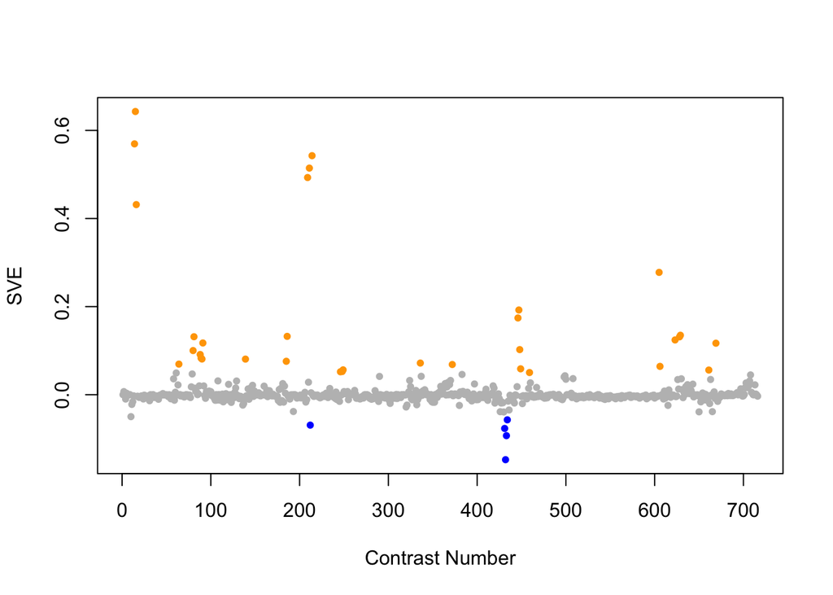

Positive SVE Contrasts:

|  | Contrast.Num | SVE | GEO.GSE | Cond.1 | Cond.2 | Mutation |
| --- | --- | --- | --- | --- | --- | --- |
| GSE9682.s2t2.vs.s2t1 | 15 | 0.64 | GSE9682 | N2-Cel-TORRNAi-fed-biological rep1 | N2-Cel-TORRNAi-fasting-biological rep1 |  |
| GSE9682.s1t2.vs.s1t1 | 14 | 0.57 | GSE9682 | N2-Cel-RhebRNAi-fed-biological rep1 | N2-Cel-RhebRNAi-fasting-biological rep1 |  |
| GSE42689.s4t1.vs.s3t1 | 214 | 0.54 | GSE42689 | mlk-1 fed 1 | mlk-1 fasted 1 |  |
| GSE42689.s4t1.vs.s1t1 | 211 | 0.51 | GSE42689 | mlk-1 fed 1 | mek-1 fasted 1 |  |
| GSE42689.s2t1.vs.s1t1 | 209 | 0.49 | GSE42689 | mek-1 fed 1 | mek-1 fasted 1 |  |
| GSE9682.s0t2.vs.s0t1 | 16 | 0.43 | GSE9682 | N2-controlRNAi-fed-biological rep1 | N2-controlRNAi-fasting-biological rep1 |  |
| GSE21784.s2t1.vs.s3t1 | 605 | 0.28 | GSE21784 | day 6 adults, biological rep 1 | day 15 adults, biological rep 1 |  |
| GSE27401.s1t1.vs.s3t1 | 447 | 0.19 | GSE27401 | Heat Killed E coli #1 | C. albicans alive #1 |  |
| GSE27401.s2t1.vs.s3t1 | 446 | 0.17 | GSE27401 | Heat Killed C. albicans #1 | C. albicans alive #1 |  |
| GSE19310A.s2t1.vs.s0t1 | 629 | 0.13 | GSE19310 | osm-7(n1515) at iso, rep1 | N2 at iso, rep1 | osm-7 |
| GSE4766.s1t2.vs.s1t1 | 186 | 0.13 | GSE4766 | Pooled glp-1 C elegans young adults_rep1 | Pooled glp-1 C elegans embryos_bleach NaOH prep_rep1 |  |
| GSE8004.s2t2.vs.s2t1 | 81 | 0.13 | GSE8004 | Larval Reference, biological rep 1 of set 1 | Embryonic Reference, biological rep 1 of set 1 |  |
| GSE19310A.s1t1.vs.s0t1 | 628 | 0.13 | GSE19310 | osm-11(n1604) at iso, rep1 | N2 at iso, rep1 | osm-11 |
| GSE20053.s1t1.vs.s0t1 | 623 | 0.12 | GSE20053 | C. elegans N2_Y. pestis KIM5_24h_Sample A | C. elegans N2_E. coli OP50_24h_Sample A |  |
| GSE6547.s1t3.vs.s1t1 | 91 | 0.12 | GSE6547 | lin-35(n745) worms at L4 stage, first replicate | lin-35(n745) worms at embryonic stage, first replicate |  |
| GSE15016.s3t1.vs.s0t1 | 669 | 0.12 | GSE15016 | young adult_24hr DEHP exposure_rep1 | young adult_not exposured_rep1 |  |
| GSE27401.s1t1.vs.s2t1 | 448 | 0.10 | GSE27401 | Heat Killed E coli #1 | Heat Killed C. albicans #1 |  |
| GSE8004.s3t2.vs.s3t1 | 80 | 0.10 | GSE8004 | Larval Pan-neural, biological rep 1 of set 2 | Embryonic Pan-neural, biological rep 1 of set 1 |  |
| GSE6547.s0t2.vs.s0t1 | 88 | 0.09 | GSE6547 | N2 (wt) worms at L1 stage, first replicate | N2 (wt) worms at embryonic stage, first replicate |  |
| GSE6547.s0t3.vs.s0t1 | 89 | 0.08 | GSE6547 | N2 (wt) worms at L4 stage, first replicate | N2 (wt) worms at embryonic stage, first replicate |  |
| GSE6547.s1t2.vs.s1t1 | 90 | 0.08 | GSE6547 | lin-35(n745) worms at L1 stage, first replicate | lin-35(n745) worms at embryonic stage, first replicate |  |
| GSE51691.s3t1.vs.s2t1 | 139 | 0.08 | GSE51691 | day8 hermaphrodite utx-1 RNAi -males rep 1 | day8 hermaphrodite +males rep 1 |  |
| GSE4766.s1t3.vs.s1t1 | 185 | 0.08 | GSE4766 | Pooled glp-1 C elegans old adults_rep1 | Pooled glp-1 C elegans embryos_bleach NaOH prep_rep1 |  |
| GSE38997.s4t2.vs.s2t2 | 336 | 0.07 | GSE38997 | experiment 4 UVC-exposed samples at 24 h 4u24 | experiment 4 EtBr-exposed samples at 24 h 4e24 |  |
| GSE8696.s3t1.vs.s1t1 | 64 | 0.07 | GSE8696 | 500 uM hemin (500A) | 4 uM hemin (4A) |  |
| GSE35360C.s2t1.vs.s0t1 | 372 | 0.07 | GSE35360 | HFHQ 3d_2.0_rep1 | HFHQ 3d control_rep1 |  |
| GSE21784.s1t1.vs.s3t1 | 606 | 0.06 | GSE21784 | L4 larvae, biological rep1 | day 15 adults, biological rep 1 |  |
| GSE25831.s1t1.vs.s2t1 | 449 | 0.06 | GSE25831 | WT_fedL1_rep1 | mixed embryo XX_WT-N_080307_A |  |
| GSE42192.s2t2.vs.s0t2 | 249 | 0.06 | GSE42192 | C.elegans fed with CNCM I-4317 10 days rep1 | C.elegans fed with E.coli OP50 10 days rep1 |  |
| GSE15159.s1t1.vs.s0t1 | 661 | 0.06 | GSE15159 | glp-1_control_2007_rep1 | N2_control_2007_rep1 | glp-1 |
| GSE42192.s1t2.vs.s0t2 | 248 | 0.05 | GSE42192 | C.elegans fed with CNCM I-3690 10 days rep1 | C.elegans fed with E.coli OP50 10 days rep1 |  |
| GSE42592C.s1t3.vs.s1t2 | 246 | 0.05 | GSE42592 | mercury_low_expose-8h_rep1 | mercury_low_expose-4h_rep1 |  |
| GSE23843B.s1t1.vs.s0t1 | 459 | 0.05 | GSE23843 | RNP-8 rnp-8(q784)-IP, biological replicate 1 | RNP-8 wt-IP, biological replicate 1 |  |

Negative SVE Contrasts:

|  | Contrast.Num | SVE | GEO.GSE | Cond.1 | Cond.2 | Mutation |
| --- | --- | --- | --- | --- | --- | --- |
| GSE27677A.s2t2.vs.s2t1 | 432 | -0.15 | GSE27677 | jun-1, Fast , rep 1 | jun-1, Fed , rep 1 |  |
| GSE27677A.s1t2.vs.s1t1 | 433 | -0.09 | GSE27677 | kgb-1, Fast , rep 1 | kgb-1, Fed , rep 1 |  |
| GSE27677A.s3t2.vs.s3t1 | 431 | -0.08 | GSE27677 | daf-16, Fast , rep 1 | daf-16, Fed , rep 1 |  |
| GSE42689.s3t1.vs.s2t1 | 212 | -0.07 | GSE42689 | mlk-1 fasted 1 | mek-1 fed 1 |  |
| GSE27677A.s0t2.vs.s0t1 | 434 | -0.06 | GSE27677 | N2, Fast , rep 1 | N2, Fed , rep 1 |  |

$~$

#### Contrast SVE, Down-Regulated Genes Only:

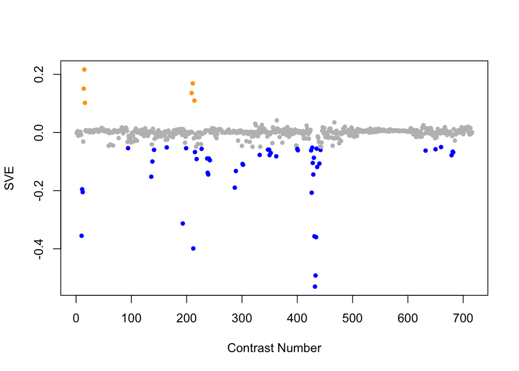

Positive SVE Contrasts:

|  | Contrast.Num | SVE | GEO.GSE | Cond.1 | Cond.2 | Mutation |
| --- | --- | --- | --- | --- | --- | --- |
| GSE9682.s2t2.vs.s2t1 | 15 | 0.22 | GSE9682 | N2-Cel-TORRNAi-fed-biological rep1 | N2-Cel-TORRNAi-fasting-biological rep1 |  |
| GSE42689.s4t1.vs.s1t1 | 211 | 0.17 | GSE42689 | mlk-1 fed 1 | mek-1 fasted 1 |  |
| GSE9682.s1t2.vs.s1t1 | 14 | 0.15 | GSE9682 | N2-Cel-RhebRNAi-fed-biological rep1 | N2-Cel-RhebRNAi-fasting-biological rep1 |  |
| GSE42689.s2t1.vs.s1t1 | 209 | 0.14 | GSE42689 | mek-1 fed 1 | mek-1 fasted 1 |  |
| GSE42689.s4t1.vs.s3t1 | 214 | 0.11 | GSE42689 | mlk-1 fed 1 | mlk-1 fasted 1 |  |
| GSE9682.s0t2.vs.s0t1 | 16 | 0.10 | GSE9682 | N2-controlRNAi-fed-biological rep1 | N2-controlRNAi-fasting-biological rep1 |  |

Negative SVE Contrasts:

|  | Contrast.Num | SVE | GEO.GSE | Cond.1 | Cond.2 | Mutation |
| --- | --- | --- | --- | --- | --- | --- |
| GSE27677A.s2t2.vs.s2t1 | 432 | -0.53 | GSE27677 | jun-1, Fast , rep 1 | jun-1, Fed , rep 1 |  |
| GSE27677A.s1t2.vs.s1t1 | 433 | -0.49 | GSE27677 | kgb-1, Fast , rep 1 | kgb-1, Fed , rep 1 |  |
| GSE42689.s3t1.vs.s2t1 | 212 | -0.40 | GSE42689 | mlk-1 fasted 1 | mek-1 fed 1 |  |
| GSE27677A.s0t2.vs.s0t1 | 434 | -0.36 | GSE27677 | N2, Fast , rep 1 | N2, Fed , rep 1 |  |
| GSE27677A.s3t2.vs.s3t1 | 431 | -0.36 | GSE27677 | daf-16, Fast , rep 1 | daf-16, Fed , rep 1 |  |
| GSE9682.s1t1.vs.s0t1 | 10 | -0.36 | GSE9682 | N2-Cel-RhebRNAi-fasting-biological rep1 | N2-controlRNAi-fasting-biological rep1 | Rheb |
| GSE45292.s1t1.vs.s0t1 | 193 | -0.31 | GSE45292 | N2 Rifampicin, Biological rep1 | N2 DMSO, Biological rep1 |  |
| GSE27677A.s2t2.vs.s0t2 | 426 | -0.21 | GSE27677 | jun-1, Fast , rep 1 | N2, Fast , rep 1 | 40694 |
| GSE9682.s1t2.vs.s0t2 | 12 | -0.20 | GSE9682 | N2-Cel-RhebRNAi-fed-biological rep1 | N2-controlRNAi-fed-biological rep1 | Rheb |
| GSE9682.s2t1.vs.s0t1 | 11 | -0.20 | GSE9682 | N2-Cel-TORRNAi-fasting-biological rep1 | N2-controlRNAi-fasting-biological rep1 | TOR |
| GSE41366C.s2t4.vs.s0t4 | 287 | -0.19 | GSE41366 | high_DDVP-continuous_expose-20h_harvest-rep1 | control-continuous_expose-14h_harvest-rep1 |  |
| GSE51691.s2t1.vs.s1t1 | 136 | -0.15 | GSE51691 | day8 hermaphrodite +males rep 1 | day8 hermaphrodite -males rep 1 |  |
| GSE27677A.s2t1.vs.s0t1 | 429 | -0.14 | GSE27677 | jun-1, Fed , rep 1 | N2, Fed , rep 1 | 40694 |
| GSE42592C.s2t2.vs.s0t2 | 239 | -0.14 | GSE42592 | mercury_mid_expose-4h_rep1 | mercury_control_expose-4h_rep1 |  |
| GSE42592C.s1t2.vs.s0t2 | 238 | -0.14 | GSE42592 | mercury_low_expose-4h_rep1 | mercury_control_expose-4h_rep1 |  |
| GSE41366C.s2t5.vs.s0t5 | 289 | -0.13 | GSE41366 | high_DDVP-continuous_expose-26h_harvest-rep1 | control-continuous_expose-20h_harvest-rep1 |  |
| GSE27677B.s1t9.vs.s0t9 | 436 | -0.12 | GSE27677 | N2, Fast 48 h, rep 1 | N2, Fed 48 h, rep 1 |  |
| GSE41366C.s2t5.vs.s2t1 | 302 | -0.11 | GSE41366 | high_DDVP-continuous_expose-26h_harvest-rep1 | high_DDVP-continuous_expose-2h_harvest-rep1 |  |
| GSE41366C.s2t4.vs.s2t1 | 301 | -0.11 | GSE41366 | high_DDVP-continuous_expose-20h_harvest-rep1 | high_DDVP-continuous_expose-2h_harvest-rep1 |  |
| GSE27677B.s1t2.vs.s1t1 | 440 | -0.11 | GSE27677 | N2, Fast 3 h, rep 1 | N2, Fed 0 h, rep 1 |  |
| GSE27677A.s3t1.vs.s0t1 | 428 | -0.10 | GSE27677 | daf-16, Fed , rep 1 | N2, Fed , rep 1 | daf-16 |
| GSE51691.s4t1.vs.s1t1 | 138 | -0.10 | GSE51691 | day8 hermaphrodite utx-1 RNAi +males rep 1 | day8 hermaphrodite -males rep 1 |  |
| GSE42592C.s2t3.vs.s0t3 | 242 | -0.10 | GSE42592 | mercury_mid_expose-8h_rep1 | mercury_control_expose-8h_rep1 |  |
| GSE42592A.s3t3.vs.s0t3 | 218 | -0.09 | GSE42592 | acrylamide_high_expose-8h_rep1 | acrylamide_control_expose-8h_rep1 |  |
| GSE42592C.s3t2.vs.s0t2 | 237 | -0.09 | GSE42592 | mercury_high_expose-4h_rep1 | mercury_control_expose-4h_rep1 |  |
| GSE42592C.s3t3.vs.s0t3 | 240 | -0.09 | GSE42592 | mercury_high_expose-8h_rep1 | mercury_control_expose-8h_rep1 |  |
| GSE27677A.s1t1.vs.s0t1 | 430 | -0.09 | GSE27677 | kgb-1, Fed , rep 1 | N2, Fed , rep 1 | kgb-1 |
| GSE37266.s1t1.vs.s0t1 | 362 | -0.08 | GSE37266 | RPW-24 G | DMSO G |  |
| GSE12298A.s3t1.vs.s0t1 | 679 | -0.08 | GSE12298 | dichlorvos_high_dose-rep1 | dichlorvos_control-rep1 |  |
| GSE38997.s3t3.vs.s3t1 | 350 | -0.08 | GSE38997 | experiment 1 UVC- and EtBr-exposed samples at 48 h 1eu48 | experiment 4 UVC- and EtBr-exposed samples at 3 h 4eu3 |  |
| GSE38997.s2t2.vs.s1t2 | 332 | -0.08 | GSE38997 | experiment 4 EtBr-exposed samples at 24 h 4e24 | experiment 4 control samples at 24 h 4c24 |  |
| GSE38997.s3t2.vs.s3t1 | 352 | -0.07 | GSE38997 | experiment 4 UVC- and EtBr-exposed samples at 24 h 4eu24 | experiment 4 UVC- and EtBr-exposed samples at 3 h 4eu3 |  |
| GSE12298B.s3t1.vs.s0t1 | 682 | -0.07 | GSE12298 | fenamiphos_high_dose-rep1 | fenamiphos_control-rep1 |  |
| GSE42592A.s3t2.vs.s0t2 | 215 | -0.07 | GSE42592 | acrylamide_high_expose-4h_rep1 | acrylamide_control_expose-4h_rep1 |  |
| GSE12298A.s2t1.vs.s0t1 | 681 | -0.07 | GSE12298 | dichlorvos_mid_dose-rep1 | dichlorvos_control-rep1 |  |
| GSE19310B.s1t2.vs.s1t1 | 632 | -0.06 | GSE19310 | N2 at 200 for 1 hour, rep1 | N2 at 200 for 15min, rep1 |  |
| GSE27677A.s3t2.vs.s0t2 | 425 | -0.06 | GSE27677 | daf-16, Fast , rep 1 | N2, Fast , rep 1 | daf-16 |
| GSE30505.s1t2.vs.s3t2 | 401 | -0.06 | GSE30505 | Day 8 N2 (WT) E.V. #1 | Day 8 glp-1 E.V. #1 | glp-1 |
| GSE27677B.s1t9.vs.s1t1 | 442 | -0.06 | GSE27677 | N2, Fast 48 h, rep 1 | N2, Fed 0 h, rep 1 |  |
| GSE51691.s4t1.vs.s3t1 | 141 | -0.06 | GSE51691 | day8 hermaphrodite utx-1 RNAi +males rep 1 | day8 hermaphrodite utx-1 RNAi -males rep 1 |  |
| GSE38997.s2t2.vs.s2t1 | 349 | -0.06 | GSE38997 | experiment 4 EtBr-exposed samples at 24 h 4e24 | experiment 4 EtBr-exposed samples at 3 h 4e3 |  |
| GSE38997.s2t3.vs.s2t1 | 347 | -0.06 | GSE38997 | experiment 1 EtBr-exposed samples at 48 h 1e48 | experiment 4 EtBr-exposed samples at 3 h 4e3 |  |
| GSE16405.s3t1.vs.s1t1 | 650 | -0.06 | GSE16405 | nth-1;xpa-1_1 | N2_1 | nth-1;xpa-1 |
| GSE30505.s2t2.vs.s3t2 | 400 | -0.06 | GSE30505 | Day 8 N2 (WT) ash-2 #1 | Day 8 glp-1 E.V. #1 | ash-2(RNAi) vs. glp-1 |
| GSE42592B.s1t2.vs.s0t2 | 227 | -0.06 | GSE42592 | cadmium_low_expose-4h_rep1 | cadmium_control_expose-4h_rep1 |  |
| GSE27677B.s1t7.vs.s0t7 | 435 | -0.06 | GSE27677 | N2, Fast 24 h, rep 1 | N2, Fed 24 h, rep 1 |  |
| GSE43959.s1t2.vs.s4t2 | 199 | -0.05 | GSE43959 | N2 gravid adult on E. coli OP50 rep 1 | N2 gravid adult on 1:1000 Comamonas DA1877 rep 1 |  |
| GSE5801.s3t1.vs.s2t1 | 94 | -0.05 | GSE5801 | daf2pmk1_RepA | daf2daf16_RepA |  |
| GSE27677A.s1t2.vs.s0t2 | 427 | -0.05 | GSE27677 | kgb-1, Fast , rep 1 | N2, Fast , rep 1 | kgb-1 |
| GSE47778.s1t2.vs.s2t2 | 164 | -0.05 | GSE47778 | N2; starvation; replicate 1 | daf-2; starvation; replicate 1 | daf-2 |
| GSE15527.s2t1.vs.s1t1 | 660 | -0.05 | GSE15527 | sma-6 L4 worm, biological rep1 | dbl-1 L4 worm, biological rep1 | dbl-1 |

$~$

$~$

#### GO Term Enrichment:

This analysis tests each hemi-module for enrichment of specific GO terms. Only gene-level annotations (e.g., as would be found on the gene’s page in Wormbase) are tested - the hierarchical structure of the GO ontology is not taken into account.

*Note: At least the top two most enriched terms from each GO domain (BP/MF/CC) are shown, even when not statistically significant.*

##### Enriched GO terms: Hemi-module A

| ID | GO.Term | GO Domain | Raw p-value | Adj p-value |
| --- | --- | --- | --- | --- |
| [GO_0045087](http://amigo.geneontology.org/amigo/term/GO:0045087) | innate immune response | BP | 2.24e-30 | 8.16e-27 |
| [GO_0050830](http://amigo.geneontology.org/amigo/term/GO:0050830) | defense response to Gram-positive bacterium | BP | 9.46e-15 | 1.72e-11 |
| [GO_0006508](http://amigo.geneontology.org/amigo/term/GO:0006508) | proteolysis | BP | 2.87e-14 | 3.48e-11 |
| [GO_0006629](http://amigo.geneontology.org/amigo/term/GO:0006629) | lipid metabolic process | BP | 4.40e-12 | 4.00e-09 |
| [GO_0051603](http://amigo.geneontology.org/amigo/term/GO:0051603) | proteolysis involved in cellular protein catabolic process | BP | 6.64e-12 | 4.84e-09 |
| [GO_0030163](http://amigo.geneontology.org/amigo/term/GO:0030163) | protein catabolic process | BP | 1.77e-08 | 1.08e-05 |
| [GO_0009253](http://amigo.geneontology.org/amigo/term/GO:0009253) | peptidoglycan catabolic process | BP | 1.03e-07 | 5.36e-05 |
| [GO_0008152](http://amigo.geneontology.org/amigo/term/GO:0008152) | metabolic process | BP | 2.28e-06 | 1.04e-03 |
| [GO_0002376](http://amigo.geneontology.org/amigo/term/GO:0002376) | immune system process | BP | 4.72e-06 | 1.91e-03 |
| [GO_0050829](http://amigo.geneontology.org/amigo/term/GO:0050829) | defense response to Gram-negative bacterium | BP | 3.12e-05 | 1.11e-02 |
| [GO_0006665](http://amigo.geneontology.org/amigo/term/GO:0006665) | sphingolipid metabolic process | BP | 3.37e-05 | 1.11e-02 |
| [GO_0008202](http://amigo.geneontology.org/amigo/term/GO:0008202) | steroid metabolic process | BP | 4.55e-05 | 1.38e-02 |
| [GO_0016998](http://amigo.geneontology.org/amigo/term/GO:0016998) | cell wall macromolecule catabolic process | BP | 5.63e-05 | 1.58e-02 |
| [GO_0016042](http://amigo.geneontology.org/amigo/term/GO:0016042) | lipid catabolic process | BP | 7.76e-05 | 2.02e-02 |
| [GO_0006355](http://amigo.geneontology.org/amigo/term/GO:0006355) | regulation of transcription, DNA-templated | BP | 9.36e-05 | 2.27e-02 |
| [GO_0009405](http://amigo.geneontology.org/amigo/term/GO:0009405) | pathogenesis | BP | 3.24e-04 | 6.94e-02 |
| [GO_0035915](http://amigo.geneontology.org/amigo/term/GO:0035915) | pore formation in membrane of other organism | BP | 3.24e-04 | 6.94e-02 |
| [GO_0007275](http://amigo.geneontology.org/amigo/term/GO:0007275) | multicellular organism development | BP | 4.42e-04 | 8.47e-02 |
| [GO_0016310](http://amigo.geneontology.org/amigo/term/GO:0016310) | phosphorylation | BP | 4.42e-04 | 8.47e-02 |
| [GO_0016787](http://amigo.geneontology.org/amigo/term/GO:0016787) | hydrolase activity | MF | 5.77e-24 | 1.18e-20 |
| [GO_0030246](http://amigo.geneontology.org/amigo/term/GO:0030246) | carbohydrate binding | MF | 3.43e-18 | 3.50e-15 |
| [GO_0008233](http://amigo.geneontology.org/amigo/term/GO:0008233) | peptidase activity | MF | 5.36e-12 | 3.65e-09 |
| [GO_0004190](http://amigo.geneontology.org/amigo/term/GO:0004190) | aspartic-type endopeptidase activity | MF | 1.12e-10 | 5.74e-08 |
| [GO_0008234](http://amigo.geneontology.org/amigo/term/GO:0008234) | cysteine-type peptidase activity | MF | 1.94e-08 | 7.94e-06 |
| [GO_0004197](http://amigo.geneontology.org/amigo/term/GO:0004197) | cysteine-type endopeptidase activity | MF | 5.67e-08 | 1.93e-05 |
| [GO_0003796](http://amigo.geneontology.org/amigo/term/GO:0003796) | lysozyme activity | MF | 4.27e-07 | 1.25e-04 |
| [GO_0016798](http://amigo.geneontology.org/amigo/term/GO:0016798) | hydrolase activity, acting on glycosyl bonds | MF | 1.19e-06 | 2.89e-04 |
| [GO_0003677](http://amigo.geneontology.org/amigo/term/GO:0003677) | DNA binding | MF | 1.27e-06 | 2.89e-04 |
| [GO_0016788](http://amigo.geneontology.org/amigo/term/GO:0016788) | hydrolase activity, acting on ester bonds | MF | 4.27e-06 | 8.72e-04 |
| [GO_0005524](http://amigo.geneontology.org/amigo/term/GO:0005524) | ATP binding | MF | 1.59e-05 | 2.80e-03 |
| [GO_0005515](http://amigo.geneontology.org/amigo/term/GO:0005515) | protein binding | MF | 1.65e-05 | 2.80e-03 |
| [GO_0000166](http://amigo.geneontology.org/amigo/term/GO:0000166) | nucleotide binding | MF | 1.82e-05 | 2.86e-03 |
| [GO_0004180](http://amigo.geneontology.org/amigo/term/GO:0004180) | carboxypeptidase activity | MF | 2.93e-05 | 4.19e-03 |
| [GO_0004185](http://amigo.geneontology.org/amigo/term/GO:0004185) | serine-type carboxypeptidase activity | MF | 3.07e-05 | 4.19e-03 |
| [GO_0003993](http://amigo.geneontology.org/amigo/term/GO:0003993) | acid phosphatase activity | MF | 4.55e-05 | 5.81e-03 |
| [GO_0003700](http://amigo.geneontology.org/amigo/term/GO:0003700) | DNA-binding transcription factor activity | MF | 2.86e-04 | 3.44e-02 |
| [GO_0003676](http://amigo.geneontology.org/amigo/term/GO:0003676) | nucleic acid binding | MF | 3.14e-04 | 3.57e-02 |
| [GO_0016301](http://amigo.geneontology.org/amigo/term/GO:0016301) | kinase activity | MF | 5.14e-04 | 5.52e-02 |
| [GO_0008239](http://amigo.geneontology.org/amigo/term/GO:0008239) | dipeptidyl-peptidase activity | MF | 6.32e-04 | 6.46e-02 |
| [GO_0004620](http://amigo.geneontology.org/amigo/term/GO:0004620) | phospholipase activity | MF | 8.58e-04 | 7.26e-02 |
| [GO_0004672](http://amigo.geneontology.org/amigo/term/GO:0004672) | protein kinase activity | MF | 8.86e-04 | 7.26e-02 |
| [GO_0004531](http://amigo.geneontology.org/amigo/term/GO:0004531) | deoxyribonuclease II activity | MF | 9.60e-04 | 7.26e-02 |
| [GO_0004558](http://amigo.geneontology.org/amigo/term/GO:0004558) | alpha-1,4-glucosidase activity | MF | 9.60e-04 | 7.26e-02 |
| [GO_0017040](http://amigo.geneontology.org/amigo/term/GO:0017040) | N-acylsphingosine amidohydrolase activity | MF | 9.60e-04 | 7.26e-02 |
| [GO_0051861](http://amigo.geneontology.org/amigo/term/GO:0051861) | glycolipid binding | MF | 9.60e-04 | 7.26e-02 |
| [GO_0102121](http://amigo.geneontology.org/amigo/term/GO:0102121) | ceramidase activity | MF | 9.60e-04 | 7.26e-02 |
| [GO_0043565](http://amigo.geneontology.org/amigo/term/GO:0043565) | sequence-specific DNA binding | MF | 1.03e-03 | 7.52e-02 |
| [GO_0005764](http://amigo.geneontology.org/amigo/term/GO:0005764) | lysosome | CC | 1.71e-17 | 1.59e-14 |
| [GO_0005634](http://amigo.geneontology.org/amigo/term/GO:0005634) | nucleus | CC | 8.80e-17 | 4.08e-14 |
| [GO_0045121](http://amigo.geneontology.org/amigo/term/GO:0045121) | membrane raft | CC | 4.30e-09 | 1.33e-06 |
| [GO_0016020](http://amigo.geneontology.org/amigo/term/GO:0016020) | membrane | CC | 1.69e-07 | 3.91e-05 |
| [GO_0016021](http://amigo.geneontology.org/amigo/term/GO:0016021) | integral component of membrane | CC | 8.10e-07 | 1.50e-04 |
| [GO_0005615](http://amigo.geneontology.org/amigo/term/GO:0005615) | extracellular space | CC | 1.97e-06 | 3.04e-04 |
| [GO_0005737](http://amigo.geneontology.org/amigo/term/GO:0005737) | cytoplasm | CC | 2.71e-04 | 3.60e-02 |

##### Enriched GO terms: Hemi-module B

| ID | GO.Term | GO Domain | Raw p-value | Adj p-value |
| --- | --- | --- | --- | --- |
| [GO_0003333](http://amigo.geneontology.org/amigo/term/GO:0003333) | amino acid transmembrane transport | BP | 5.99e-04 | 1.00e+00 |
| [GO_0035725](http://amigo.geneontology.org/amigo/term/GO:0035725) | sodium ion transmembrane transport | BP | 4.20e-03 | 1.00e+00 |
| [GO_0015171](http://amigo.geneontology.org/amigo/term/GO:0015171) | amino acid transmembrane transporter activity | MF | 4.02e-04 | 8.22e-01 |
| [GO_0016971](http://amigo.geneontology.org/amigo/term/GO:0016971) | flavin-linked sulfhydryl oxidase activity | MF | 8.62e-03 | 1.00e+00 |
| [GO_0031224](http://amigo.geneontology.org/amigo/term/GO:0031224) | intrinsic component of membrane | CC | 4.32e-03 | 1.00e+00 |
| [GO_0005737](http://amigo.geneontology.org/amigo/term/GO:0005737) | cytoplasm | CC | 1.90e-02 | 1.00e+00 |

$~$

$~$

#### Tissue Enrichment:

This analysis tests each hemi-module for enrichment of genes associated with anatomy terms. Negative enrichment scores indicate fewer hemi-module genes than expected by random chance were associated with the anatomy term in question.

##### Enriched tissues: Hemi-module A

| ID | Anatomy.Term | Definition | Raw p-value | Adj p-value |
| --- | --- | --- | --- | --- |
| [WBbt_0005772](https://wormbase.org/species/all/anatomy_term/WBbt:0005772) | intestine | A chain of very large cuboidal cells forming a wide central lumen in which food arrives from the posterior pharynx, is digested, and from which waste products proceed to the rectum. Intestinal rings f… | 1.38e-16 | 3.36e-13 |

##### Enriched tissues: Hemi-module B

No significant annotations.

$~$

$~$

#### HOMER promoter motif enrichment:

This analysis tests each hemi-module for enrichment of 108 known *C. elegans* transcription factor binding site motifs (see [108 CE motifs](https://katiepod.github.io//all.worm.motifs.html)) using the HOMER (Hypergeometric Optimization of Motif EnRichment) software (see [PMID:20513432](https://pubmed.ncbi.nlm.nih.gov/20513432)). HOMER was run using default parameters on sequences 1 kb upstream of the transcription start site.

##### Motif enrichment: Hemi-module A

Total target sequences = 286  
Total background sequences = 41117  
* - possible false positive

Rank

Motif

P-value

log P-pvalue

% of Targets

% of Background

STD(Bg STD)

Best Match/Details

Motif File

1

[figure not shown]

1e-61

-1.426e+02

68.53%

22.00%

240.6bp (325.6bp)

PQM-1(?)/cElegans-L3-ChIP-Seq(modEncode)/Homer(0.993)  
[More Information](https://katiepod.github.io/HomerResults/m100_a_hemi_genes.txt.out.1kb/homerResults/motif1.info.html) | [Similar Motifs Found](https://katiepod.github.io/HomerResults/m100_a_hemi_genes.txt.out.1kb/homerResults/motif1.similar.html)

[motif file (matrix)](https://katiepod.github.io/HomerResults/m100_a_hemi_genes.txt.out.1kb/homerResults/motif1.motif)

2 *

[figure not shown]

1e-11

-2.761e+01

18.88%

6.37%

295.7bp (297.3bp)

CES-1(Homeobox)/cElegans-L1-CES1-ChIP-Seq(modEncode)/Homer(0.633)  
[More Information](https://katiepod.github.io/HomerResults/m100_a_hemi_genes.txt.out.1kb/homerResults/motif2.info.html) | [Similar Motifs Found](https://katiepod.github.io/HomerResults/m100_a_hemi_genes.txt.out.1kb/homerResults/motif2.similar.html)

[motif file (matrix)](https://katiepod.github.io/HomerResults/m100_a_hemi_genes.txt.out.1kb/homerResults/motif2.motif)

3 *

[figure not shown]

1e-11

-2.699e+01

3.15%

0.06%

308.9bp (314.6bp)

blmp-1/MA0537.1/Jaspar(0.515)  
[More Information](https://katiepod.github.io/HomerResults/m100_a_hemi_genes.txt.out.1kb/homerResults/motif3.info.html) | [Similar Motifs Found](https://katiepod.github.io/HomerResults/m100_a_hemi_genes.txt.out.1kb/homerResults/motif3.similar.html)

[motif file (matrix)](https://katiepod.github.io/HomerResults/m100_a_hemi_genes.txt.out.1kb/homerResults/motif3.motif)

4 *

[figure not shown]

1e-11

-2.671e+01

3.15%

0.07%

304.4bp (288.4bp)

zip-8/MA1704.1/Jaspar(0.690)  
[More Information](https://katiepod.github.io/HomerResults/m100_a_hemi_genes.txt.out.1kb/homerResults/motif4.info.html) | [Similar Motifs Found](https://katiepod.github.io/HomerResults/m100_a_hemi_genes.txt.out.1kb/homerResults/motif4.similar.html)

[motif file (matrix)](https://katiepod.github.io/HomerResults/m100_a_hemi_genes.txt.out.1kb/homerResults/motif4.motif)

5 *

[figure not shown]

1e-11

-2.668e+01

3.50%

0.10%

188.2bp (330.2bp)

pal-1/MA0924.1/Jaspar(0.643)  
[More Information](https://katiepod.github.io/HomerResults/m100_a_hemi_genes.txt.out.1kb/homerResults/motif5.info.html) | [Similar Motifs Found](https://katiepod.github.io/HomerResults/m100_a_hemi_genes.txt.out.1kb/homerResults/motif5.similar.html)

[motif file (matrix)](https://katiepod.github.io/HomerResults/m100_a_hemi_genes.txt.out.1kb/homerResults/motif5.motif)

6 *

[figure not shown]

1e-10

-2.522e+01

3.85%

0.17%

336.2bp (323.6bp)

POL008.1_DCE_S_I/Jaspar(0.596)  
[More Information](https://katiepod.github.io/HomerResults/m100_a_hemi_genes.txt.out.1kb/homerResults/motif6.info.html) | [Similar Motifs Found](https://katiepod.github.io/HomerResults/m100_a_hemi_genes.txt.out.1kb/homerResults/motif6.similar.html)

[motif file (matrix)](https://katiepod.github.io/HomerResults/m100_a_hemi_genes.txt.out.1kb/homerResults/motif6.motif)

7 *

[figure not shown]

1e-10

-2.414e+01

2.45%

0.03%

239.7bp (305.1bp)

POL009.1_DCE_S_II/Jaspar(0.599)  
[More Information](https://katiepod.github.io/HomerResults/m100_a_hemi_genes.txt.out.1kb/homerResults/motif7.info.html) | [Similar Motifs Found](https://katiepod.github.io/HomerResults/m100_a_hemi_genes.txt.out.1kb/homerResults/motif7.similar.html)

[motif file (matrix)](https://katiepod.github.io/HomerResults/m100_a_hemi_genes.txt.out.1kb/homerResults/motif7.motif)

8 *

[figure not shown]

1e-10

-2.334e+01

2.80%

0.06%

240.8bp (296.3bp)

POL004.1_CCAAT-box/Jaspar(0.560)  
[More Information](https://katiepod.github.io/HomerResults/m100_a_hemi_genes.txt.out.1kb/homerResults/motif8.info.html) | [Similar Motifs Found](https://katiepod.github.io/HomerResults/m100_a_hemi_genes.txt.out.1kb/homerResults/motif8.similar.html)

[motif file (matrix)](https://katiepod.github.io/HomerResults/m100_a_hemi_genes.txt.out.1kb/homerResults/motif8.motif)

9 *

[figure not shown]

1e-9

-2.291e+01

16.08%

5.52%

265.8bp (316.1bp)

PHA-4(Forkhead)/cElegans-Embryos-PHA4-ChIP-Seq(modEncode)/Homer(0.639)  
[More Information](https://katiepod.github.io/HomerResults/m100_a_hemi_genes.txt.out.1kb/homerResults/motif9.info.html) | [Similar Motifs Found](https://katiepod.github.io/HomerResults/m100_a_hemi_genes.txt.out.1kb/homerResults/motif9.similar.html)

[motif file (matrix)](https://katiepod.github.io/HomerResults/m100_a_hemi_genes.txt.out.1kb/homerResults/motif9.motif)

10 *

[figure not shown]

1e-9

-2.251e+01

6.64%

0.98%

225.3bp (310.6bp)

POL005.1_DPE/Jaspar(0.518)  
[More Information](https://katiepod.github.io/HomerResults/m100_a_hemi_genes.txt.out.1kb/homerResults/motif10.info.html) | [Similar Motifs Found](https://katiepod.github.io/HomerResults/m100_a_hemi_genes.txt.out.1kb/homerResults/motif10.similar.html)

[motif file (matrix)](https://katiepod.github.io/HomerResults/m100_a_hemi_genes.txt.out.1kb/homerResults/motif10.motif)

11 *

[figure not shown]

1e-9

-2.215e+01

2.80%

0.08%

265.3bp (360.2bp)

MF0002.1_bZIP_CREB/G-box-like_subclass/Jaspar(0.739)  
[More Information](https://katiepod.github.io/HomerResults/m100_a_hemi_genes.txt.out.1kb/homerResults/motif11.info.html) | [Similar Motifs Found](https://katiepod.github.io/HomerResults/m100_a_hemi_genes.txt.out.1kb/homerResults/motif11.similar.html)

[motif file (matrix)](https://katiepod.github.io/HomerResults/m100_a_hemi_genes.txt.out.1kb/homerResults/motif11.motif)

12 *

[figure not shown]

1e-9

-2.115e+01

6.64%

1.07%

305.3bp (317.2bp)

MF0007.1_bHLH(zip)_class/Jaspar(0.844)  
[More Information](https://katiepod.github.io/HomerResults/m100_a_hemi_genes.txt.out.1kb/homerResults/motif12.info.html) | [Similar Motifs Found](https://katiepod.github.io/HomerResults/m100_a_hemi_genes.txt.out.1kb/homerResults/motif12.similar.html)

[motif file (matrix)](https://katiepod.github.io/HomerResults/m100_a_hemi_genes.txt.out.1kb/homerResults/motif12.motif)

13 *

[figure not shown]

1e-9

-2.090e+01

3.85%

0.27%

267.0bp (325.6bp)

MF0001.1_ETS_class/Jaspar(0.625)  
[More Information](https://katiepod.github.io/HomerResults/m100_a_hemi_genes.txt.out.1kb/homerResults/motif13.info.html) | [Similar Motifs Found](https://katiepod.github.io/HomerResults/m100_a_hemi_genes.txt.out.1kb/homerResults/motif13.similar.html)

[motif file (matrix)](https://katiepod.github.io/HomerResults/m100_a_hemi_genes.txt.out.1kb/homerResults/motif13.motif)

14 *

[figure not shown]

1e-9

-2.087e+01

15.38%

5.47%

335.1bp (292.6bp)

MF0001.1_ETS_class/Jaspar(0.655)  
[More Information](https://katiepod.github.io/HomerResults/m100_a_hemi_genes.txt.out.1kb/homerResults/motif14.info.html) | [Similar Motifs Found](https://katiepod.github.io/HomerResults/m100_a_hemi_genes.txt.out.1kb/homerResults/motif14.similar.html)

[motif file (matrix)](https://katiepod.github.io/HomerResults/m100_a_hemi_genes.txt.out.1kb/homerResults/motif14.motif)

15 *

[figure not shown]

1e-8

-2.026e+01

2.45%

0.06%

241.6bp (280.1bp)

elt-6/MA1439.1/Jaspar(0.644)  
[More Information](https://katiepod.github.io/HomerResults/m100_a_hemi_genes.txt.out.1kb/homerResults/motif15.info.html) | [Similar Motifs Found](https://katiepod.github.io/HomerResults/m100_a_hemi_genes.txt.out.1kb/homerResults/motif15.similar.html)

[motif file (matrix)](https://katiepod.github.io/HomerResults/m100_a_hemi_genes.txt.out.1kb/homerResults/motif15.motif)

16 *

[figure not shown]

1e-8

-2.004e+01

14.69%

5.20%

296.0bp (309.9bp)

POL013.1_MED-1/Jaspar(0.636)  
[More Information](https://katiepod.github.io/HomerResults/m100_a_hemi_genes.txt.out.1kb/homerResults/motif16.info.html) | [Similar Motifs Found](https://katiepod.github.io/HomerResults/m100_a_hemi_genes.txt.out.1kb/homerResults/motif16.similar.html)

[motif file (matrix)](https://katiepod.github.io/HomerResults/m100_a_hemi_genes.txt.out.1kb/homerResults/motif16.motif)

17 *

[figure not shown]

1e-8

-1.993e+01

11.19%

3.25%

252.5bp (307.2bp)

MF0001.1_ETS_class/Jaspar(0.625)  
[More Information](https://katiepod.github.io/HomerResults/m100_a_hemi_genes.txt.out.1kb/homerResults/motif17.info.html) | [Similar Motifs Found](https://katiepod.github.io/HomerResults/m100_a_hemi_genes.txt.out.1kb/homerResults/motif17.similar.html)

[motif file (matrix)](https://katiepod.github.io/HomerResults/m100_a_hemi_genes.txt.out.1kb/homerResults/motif17.motif)

18 *

[figure not shown]

1e-8

-1.927e+01

3.15%

0.17%

225.8bp (338.0bp)

PL0012.1_hlh-2::hlh-8/Jaspar(0.697)  
[More Information](https://katiepod.github.io/HomerResults/m100_a_hemi_genes.txt.out.1kb/homerResults/motif18.info.html) | [Similar Motifs Found](https://katiepod.github.io/HomerResults/m100_a_hemi_genes.txt.out.1kb/homerResults/motif18.similar.html)

[motif file (matrix)](https://katiepod.github.io/HomerResults/m100_a_hemi_genes.txt.out.1kb/homerResults/motif18.motif)

19 *

[figure not shown]

1e-8

-1.851e+01

33.92%

19.55%

316.7bp (316.8bp)

POL008.1_DCE_S_I/Jaspar(0.710)  
[More Information](https://katiepod.github.io/HomerResults/m100_a_hemi_genes.txt.out.1kb/homerResults/motif19.info.html) | [Similar Motifs Found](https://katiepod.github.io/HomerResults/m100_a_hemi_genes.txt.out.1kb/homerResults/motif19.similar.html)

[motif file (matrix)](https://katiepod.github.io/HomerResults/m100_a_hemi_genes.txt.out.1kb/homerResults/motif19.motif)

20 *

[figure not shown]

1e-8

-1.849e+01

21.68%

10.15%

260.6bp (306.8bp)

CES-1(Homeobox)/cElegans-L1-CES1-ChIP-Seq(modEncode)/Homer(0.571)  
[More Information](https://katiepod.github.io/HomerResults/m100_a_hemi_genes.txt.out.1kb/homerResults/motif20.info.html) | [Similar Motifs Found](https://katiepod.github.io/HomerResults/m100_a_hemi_genes.txt.out.1kb/homerResults/motif20.similar.html)

[motif file (matrix)](https://katiepod.github.io/HomerResults/m100_a_hemi_genes.txt.out.1kb/homerResults/motif20.motif)

21 *

[figure not shown]

1e-7

-1.790e+01

2.80%

0.14%

287.4bp (276.6bp)

POL004.1_CCAAT-box/Jaspar(0.592)  
[More Information](https://katiepod.github.io/HomerResults/m100_a_hemi_genes.txt.out.1kb/homerResults/motif21.info.html) | [Similar Motifs Found](https://katiepod.github.io/HomerResults/m100_a_hemi_genes.txt.out.1kb/homerResults/motif21.similar.html)

[motif file (matrix)](https://katiepod.github.io/HomerResults/m100_a_hemi_genes.txt.out.1kb/homerResults/motif21.motif)

22 *

[figure not shown]

1e-7

-1.789e+01

7.69%

1.77%

293.4bp (305.2bp)

POL012.1_TATA-Box/Jaspar(0.727)  
[More Information](https://katiepod.github.io/HomerResults/m100_a_hemi_genes.txt.out.1kb/homerResults/motif22.info.html) | [Similar Motifs Found](https://katiepod.github.io/HomerResults/m100_a_hemi_genes.txt.out.1kb/homerResults/motif22.similar.html)

[motif file (matrix)](https://katiepod.github.io/HomerResults/m100_a_hemi_genes.txt.out.1kb/homerResults/motif22.motif)

23 *

[figure not shown]

1e-7

-1.778e+01

5.94%

1.05%

255.1bp (329.3bp)

POL003.1_GC-box/Jaspar(0.652)  
[More Information](https://katiepod.github.io/HomerResults/m100_a_hemi_genes.txt.out.1kb/homerResults/motif23.info.html) | [Similar Motifs Found](https://katiepod.github.io/HomerResults/m100_a_hemi_genes.txt.out.1kb/homerResults/motif23.similar.html)

[motif file (matrix)](https://katiepod.github.io/HomerResults/m100_a_hemi_genes.txt.out.1kb/homerResults/motif23.motif)

24 *

[figure not shown]

1e-7

-1.773e+01

15.03%

5.87%

291.3bp (298.7bp)

ELT-3(Gata)/cElegans-L1-ELT3-ChIP-Seq(modEncode)/Homer(0.518)  
[More Information](https://katiepod.github.io/HomerResults/m100_a_hemi_genes.txt.out.1kb/homerResults/motif24.info.html) | [Similar Motifs Found](https://katiepod.github.io/HomerResults/m100_a_hemi_genes.txt.out.1kb/homerResults/motif24.similar.html)

[motif file (matrix)](https://katiepod.github.io/HomerResults/m100_a_hemi_genes.txt.out.1kb/homerResults/motif24.motif)

25 *

[figure not shown]

1e-7

-1.753e+01

12.24%

4.20%

245.3bp (312.3bp)

MF0004.1_Nuclear_Receptor_class/Jaspar(0.707)  
[More Information](https://katiepod.github.io/HomerResults/m100_a_hemi_genes.txt.out.1kb/homerResults/motif25.info.html) | [Similar Motifs Found](https://katiepod.github.io/HomerResults/m100_a_hemi_genes.txt.out.1kb/homerResults/motif25.similar.html)

[motif file (matrix)](https://katiepod.github.io/HomerResults/m100_a_hemi_genes.txt.out.1kb/homerResults/motif25.motif)

26 *

[figure not shown]

1e-6

-1.570e+01

11.54%

4.12%

271.0bp (304.5bp)

atf-7/MA1438.1/Jaspar(0.663)  
[More Information](https://katiepod.github.io/HomerResults/m100_a_hemi_genes.txt.out.1kb/homerResults/motif26.info.html) | [Similar Motifs Found](https://katiepod.github.io/HomerResults/m100_a_hemi_genes.txt.out.1kb/homerResults/motif26.similar.html)

[motif file (matrix)](https://katiepod.github.io/HomerResults/m100_a_hemi_genes.txt.out.1kb/homerResults/motif26.motif)

27 *

[figure not shown]

1e-6

-1.568e+01

20.98%

10.46%

307.4bp (313.8bp)

SD0002.1_at_AC_acceptor/Jaspar(0.679)  
[More Information](https://katiepod.github.io/HomerResults/m100_a_hemi_genes.txt.out.1kb/homerResults/motif27.info.html) | [Similar Motifs Found](https://katiepod.github.io/HomerResults/m100_a_hemi_genes.txt.out.1kb/homerResults/motif27.similar.html)

[motif file (matrix)](https://katiepod.github.io/HomerResults/m100_a_hemi_genes.txt.out.1kb/homerResults/motif27.motif)

28 *

[figure not shown]

1e-5

-1.274e+01

6.99%

2.05%

264.2bp (319.1bp)

ceh-22/MA0264.1/Jaspar(0.631)  
[More Information](https://katiepod.github.io/HomerResults/m100_a_hemi_genes.txt.out.1kb/homerResults/motif28.info.html) | [Similar Motifs Found](https://katiepod.github.io/HomerResults/m100_a_hemi_genes.txt.out.1kb/homerResults/motif28.similar.html)

[motif file (matrix)](https://katiepod.github.io/HomerResults/m100_a_hemi_genes.txt.out.1kb/homerResults/motif28.motif)

29 *

[figure not shown]

1e-5

-1.239e+01

6.29%

1.73%

273.5bp (311.0bp)

unc-30/MA1443.1/Jaspar(0.577)  
[More Information](https://katiepod.github.io/HomerResults/m100_a_hemi_genes.txt.out.1kb/homerResults/motif29.info.html) | [Similar Motifs Found](https://katiepod.github.io/HomerResults/m100_a_hemi_genes.txt.out.1kb/homerResults/motif29.similar.html)

[motif file (matrix)](https://katiepod.github.io/HomerResults/m100_a_hemi_genes.txt.out.1kb/homerResults/motif29.motif)

30 *

[figure not shown]

1e-5

-1.230e+01

12.94%

5.75%

250.8bp (317.9bp)

SD0002.1_at_AC_acceptor/Jaspar(0.680)  
[More Information](https://katiepod.github.io/HomerResults/m100_a_hemi_genes.txt.out.1kb/homerResults/motif30.info.html) | [Similar Motifs Found](https://katiepod.github.io/HomerResults/m100_a_hemi_genes.txt.out.1kb/homerResults/motif30.similar.html)

[motif file (matrix)](https://katiepod.github.io/HomerResults/m100_a_hemi_genes.txt.out.1kb/homerResults/motif30.motif)

31 *

[figure not shown]

1e-5

-1.200e+01

10.14%

4.00%

276.2bp (314.1bp)

ces-2/MA0922.1/Jaspar(0.569)  
[More Information](https://katiepod.github.io/HomerResults/m100_a_hemi_genes.txt.out.1kb/homerResults/motif31.info.html) | [Similar Motifs Found](https://katiepod.github.io/HomerResults/m100_a_hemi_genes.txt.out.1kb/homerResults/motif31.similar.html)

[motif file (matrix)](https://katiepod.github.io/HomerResults/m100_a_hemi_genes.txt.out.1kb/homerResults/motif31.motif)

32 *

[figure not shown]

1e-4

-1.022e+01

1.75%

0.12%

185.2bp (306.7bp)

PL0001.1_hlh-11/Jaspar(0.612)  
[More Information](https://katiepod.github.io/HomerResults/m100_a_hemi_genes.txt.out.1kb/homerResults/motif32.info.html) | [Similar Motifs Found](https://katiepod.github.io/HomerResults/m100_a_hemi_genes.txt.out.1kb/homerResults/motif32.similar.html)

[motif file (matrix)](https://katiepod.github.io/HomerResults/m100_a_hemi_genes.txt.out.1kb/homerResults/motif32.motif)

33 *

[figure not shown]

1e-3

-9.067e+00

11.89%

5.95%

300.7bp (317.2bp)

sma-4/MA0925.1/Jaspar(0.635)  
[More Information](https://katiepod.github.io/HomerResults/m100_a_hemi_genes.txt.out.1kb/homerResults/motif33.info.html) | [Similar Motifs Found](https://katiepod.github.io/HomerResults/m100_a_hemi_genes.txt.out.1kb/homerResults/motif33.similar.html)

[motif file (matrix)](https://katiepod.github.io/HomerResults/m100_a_hemi_genes.txt.out.1kb/homerResults/motif33.motif)

34 *

[figure not shown]

1e-3

-8.171e+00

0.70%

0.01%

97.0bp (12.8bp)

POL010.1_DCE_S_III/Jaspar(0.518)  
[More Information](https://katiepod.github.io/HomerResults/m100_a_hemi_genes.txt.out.1kb/homerResults/motif34.info.html) | [Similar Motifs Found](https://katiepod.github.io/HomerResults/m100_a_hemi_genes.txt.out.1kb/homerResults/motif34.similar.html)

[motif file (matrix)](https://katiepod.github.io/HomerResults/m100_a_hemi_genes.txt.out.1kb/homerResults/motif34.motif)

35 *

[figure not shown]

1e-2

-6.192e+00

2.10%

0.44%

186.8bp (296.2bp)

lin-54/MA1450.1/Jaspar(0.573)  
[More Information](https://katiepod.github.io/HomerResults/m100_a_hemi_genes.txt.out.1kb/homerResults/motif35.info.html) | [Similar Motifs Found](https://katiepod.github.io/HomerResults/m100_a_hemi_genes.txt.out.1kb/homerResults/motif35.similar.html)

[motif file (matrix)](https://katiepod.github.io/HomerResults/m100_a_hemi_genes.txt.out.1kb/homerResults/motif35.motif)

36 *

[figure not shown]

1e-1

-4.217e+00

1.05%

0.17%

158.6bp (241.6bp)

MF0011.1_HMG_class/Jaspar(0.529)  
[More Information](https://katiepod.github.io/HomerResults/m100_a_hemi_genes.txt.out.1kb/homerResults/motif36.info.html) | [Similar Motifs Found](https://katiepod.github.io/HomerResults/m100_a_hemi_genes.txt.out.1kb/homerResults/motif36.similar.html)

[motif file (matrix)](https://katiepod.github.io/HomerResults/m100_a_hemi_genes.txt.out.1kb/homerResults/motif36.motif)

37 *

[figure not shown]

1e-1

-3.050e+00

0.35%

0.02%

186.6bp (297.4bp)

MF0010.1_Homeobox_class/Jaspar(0.601)  
[More Information](https://katiepod.github.io/HomerResults/m100_a_hemi_genes.txt.out.1kb/homerResults/motif37.info.html) | [Similar Motifs Found](https://katiepod.github.io/HomerResults/m100_a_hemi_genes.txt.out.1kb/homerResults/motif37.similar.html)

[motif file (matrix)](https://katiepod.github.io/HomerResults/m100_a_hemi_genes.txt.out.1kb/homerResults/motif37.motif)

##### Motif enrichment: Hemi-module B

Total target sequences = 40  
Total background sequences = 40658  
* - possible false positive

Rank

Motif

P-value

log P-pvalue

% of Targets

% of Background

STD(Bg STD)

Best Match/Details

Motif File

1 *

[figure not shown]

1e-10

-2.445e+01

15.00%

0.13%

147.0bp (350.9bp)

ceh-22/MA0264.1/Jaspar(0.552)  
[More Information](https://katiepod.github.io/HomerResults/m100_b_hemi_genes.txt.out.1kb/homerResults/motif1.info.html) | [Similar Motifs Found](https://katiepod.github.io/HomerResults/m100_b_hemi_genes.txt.out.1kb/homerResults/motif1.similar.html)

[motif file (matrix)](https://katiepod.github.io/HomerResults/m100_b_hemi_genes.txt.out.1kb/homerResults/motif1.motif)

2 *

[figure not shown]

1e-10

-2.425e+01

32.50%

2.72%

318.8bp (322.2bp)

POL009.1_DCE_S_II/Jaspar(0.518)  
[More Information](https://katiepod.github.io/HomerResults/m100_b_hemi_genes.txt.out.1kb/homerResults/motif2.info.html) | [Similar Motifs Found](https://katiepod.github.io/HomerResults/m100_b_hemi_genes.txt.out.1kb/homerResults/motif2.similar.html)

[motif file (matrix)](https://katiepod.github.io/HomerResults/m100_b_hemi_genes.txt.out.1kb/homerResults/motif2.motif)

3 *

[figure not shown]

1e-8

-2.016e+01

17.50%

0.52%

173.3bp (251.4bp)

POL012.1_TATA-Box/Jaspar(0.694)  
[More Information](https://katiepod.github.io/HomerResults/m100_b_hemi_genes.txt.out.1kb/homerResults/motif3.info.html) | [Similar Motifs Found](https://katiepod.github.io/HomerResults/m100_b_hemi_genes.txt.out.1kb/homerResults/motif3.similar.html)

[motif file (matrix)](https://katiepod.github.io/HomerResults/m100_b_hemi_genes.txt.out.1kb/homerResults/motif3.motif)

4 *

[figure not shown]

1e-8

-1.996e+01

40.00%

6.67%

285.6bp (289.9bp)

MF0011.1_HMG_class/Jaspar(0.505)  
[More Information](https://katiepod.github.io/HomerResults/m100_b_hemi_genes.txt.out.1kb/homerResults/motif4.info.html) | [Similar Motifs Found](https://katiepod.github.io/HomerResults/m100_b_hemi_genes.txt.out.1kb/homerResults/motif4.similar.html)

[motif file (matrix)](https://katiepod.github.io/HomerResults/m100_b_hemi_genes.txt.out.1kb/homerResults/motif4.motif)

5 *

[figure not shown]

1e-7

-1.784e+01

27.50%

2.98%

232.8bp (305.3bp)

efl-1/MA0541.1/Jaspar(0.603)  
[More Information](https://katiepod.github.io/HomerResults/m100_b_hemi_genes.txt.out.1kb/homerResults/motif5.info.html) | [Similar Motifs Found](https://katiepod.github.io/HomerResults/m100_b_hemi_genes.txt.out.1kb/homerResults/motif5.similar.html)

[motif file (matrix)](https://katiepod.github.io/HomerResults/m100_b_hemi_genes.txt.out.1kb/homerResults/motif5.motif)

6 *

[figure not shown]

1e-7

-1.691e+01

22.50%

1.86%

282.5bp (313.6bp)

fkh-9/MA1440.1/Jaspar(0.616)  
[More Information](https://katiepod.github.io/HomerResults/m100_b_hemi_genes.txt.out.1kb/homerResults/motif6.info.html) | [Similar Motifs Found](https://katiepod.github.io/HomerResults/m100_b_hemi_genes.txt.out.1kb/homerResults/motif6.similar.html)

[motif file (matrix)](https://katiepod.github.io/HomerResults/m100_b_hemi_genes.txt.out.1kb/homerResults/motif6.motif)

7 *

[figure not shown]

1e-7

-1.615e+01

12.50%

0.27%

163.3bp (347.7bp)

MF0006.1_bZIP_cEBP-like_subclass/Jaspar(0.595)  
[More Information](https://katiepod.github.io/HomerResults/m100_b_hemi_genes.txt.out.1kb/homerResults/motif7.info.html) | [Similar Motifs Found](https://katiepod.github.io/HomerResults/m100_b_hemi_genes.txt.out.1kb/homerResults/motif7.similar.html)

[motif file (matrix)](https://katiepod.github.io/HomerResults/m100_b_hemi_genes.txt.out.1kb/homerResults/motif7.motif)

8 *

[figure not shown]

1e-6

-1.585e+01

17.50%

0.98%

245.7bp (314.0bp)

zfh-2/MA0928.1/Jaspar(0.581)  
[More Information](https://katiepod.github.io/HomerResults/m100_b_hemi_genes.txt.out.1kb/homerResults/motif8.info.html) | [Similar Motifs Found](https://katiepod.github.io/HomerResults/m100_b_hemi_genes.txt.out.1kb/homerResults/motif8.similar.html)

[motif file (matrix)](https://katiepod.github.io/HomerResults/m100_b_hemi_genes.txt.out.1kb/homerResults/motif8.motif)

9 *

[figure not shown]

1e-6

-1.566e+01

62.50%

23.43%

260.1bp (309.0bp)

fkh-9/MA1440.1/Jaspar(0.577)  
[More Information](https://katiepod.github.io/HomerResults/m100_b_hemi_genes.txt.out.1kb/homerResults/motif9.info.html) | [Similar Motifs Found](https://katiepod.github.io/HomerResults/m100_b_hemi_genes.txt.out.1kb/homerResults/motif9.similar.html)

[motif file (matrix)](https://katiepod.github.io/HomerResults/m100_b_hemi_genes.txt.out.1kb/homerResults/motif9.motif)

10 *

[figure not shown]

1e-6

-1.531e+01

22.50%

2.25%

253.9bp (296.4bp)

POL003.1_GC-box/Jaspar(0.633)  
[More Information](https://katiepod.github.io/HomerResults/m100_b_hemi_genes.txt.out.1kb/homerResults/motif10.info.html) | [Similar Motifs Found](https://katiepod.github.io/HomerResults/m100_b_hemi_genes.txt.out.1kb/homerResults/motif10.similar.html)

[motif file (matrix)](https://katiepod.github.io/HomerResults/m100_b_hemi_genes.txt.out.1kb/homerResults/motif10.motif)

11 *

[figure not shown]

1e-6

-1.445e+01

37.50%

8.60%

263.3bp (314.4bp)

MF0002.1_bZIP_CREB/G-box-like_subclass/Jaspar(0.703)  
[More Information](https://katiepod.github.io/HomerResults/m100_b_hemi_genes.txt.out.1kb/homerResults/motif11.info.html) | [Similar Motifs Found](https://katiepod.github.io/HomerResults/m100_b_hemi_genes.txt.out.1kb/homerResults/motif11.similar.html)

[motif file (matrix)](https://katiepod.github.io/HomerResults/m100_b_hemi_genes.txt.out.1kb/homerResults/motif11.motif)

12 *

[figure not shown]

1e-5

-1.276e+01

25.00%

3.98%

328.1bp (299.7bp)

ceh-28/MA1445.1/Jaspar(0.594)  
[More Information](https://katiepod.github.io/HomerResults/m100_b_hemi_genes.txt.out.1kb/homerResults/motif12.info.html) | [Similar Motifs Found](https://katiepod.github.io/HomerResults/m100_b_hemi_genes.txt.out.1kb/homerResults/motif12.similar.html)

[motif file (matrix)](https://katiepod.github.io/HomerResults/m100_b_hemi_genes.txt.out.1kb/homerResults/motif12.motif)

13 *

[figure not shown]

1e-4

-1.095e+01

20.00%

2.91%

262.1bp (296.5bp)

MF0006.1_bZIP_cEBP-like_subclass/Jaspar(0.660)  
[More Information](https://katiepod.github.io/HomerResults/m100_b_hemi_genes.txt.out.1kb/homerResults/motif13.info.html) | [Similar Motifs Found](https://katiepod.github.io/HomerResults/m100_b_hemi_genes.txt.out.1kb/homerResults/motif13.similar.html)

[motif file (matrix)](https://katiepod.github.io/HomerResults/m100_b_hemi_genes.txt.out.1kb/homerResults/motif13.motif)

14 *

[figure not shown]

1e-4

-9.294e+00

17.50%

2.71%

298.5bp (308.4bp)

che-1/MA0260.1/Jaspar(0.531)  
[More Information](https://katiepod.github.io/HomerResults/m100_b_hemi_genes.txt.out.1kb/homerResults/motif14.info.html) | [Similar Motifs Found](https://katiepod.github.io/HomerResults/m100_b_hemi_genes.txt.out.1kb/homerResults/motif14.similar.html)

[motif file (matrix)](https://katiepod.github.io/HomerResults/m100_b_hemi_genes.txt.out.1kb/homerResults/motif14.motif)

15 *

[figure not shown]

1e-3

-8.085e+00

20.00%

4.40%

291.3bp (316.5bp)

sma-4/MA0925.1/Jaspar(0.493)  
[More Information](https://katiepod.github.io/HomerResults/m100_b_hemi_genes.txt.out.1kb/homerResults/motif15.info.html) | [Similar Motifs Found](https://katiepod.github.io/HomerResults/m100_b_hemi_genes.txt.out.1kb/homerResults/motif15.similar.html)

[motif file (matrix)](https://katiepod.github.io/HomerResults/m100_b_hemi_genes.txt.out.1kb/homerResults/motif15.motif)

16 *

[figure not shown]

1e-3

-6.923e+00

2.50%

0.00%

58.7bp (0.0bp)

hlh-30/MA1449.1/Jaspar(0.542)  
[More Information](https://katiepod.github.io/HomerResults/m100_b_hemi_genes.txt.out.1kb/homerResults/motif16.info.html) | [Similar Motifs Found](https://katiepod.github.io/HomerResults/m100_b_hemi_genes.txt.out.1kb/homerResults/motif16.similar.html)

[motif file (matrix)](https://katiepod.github.io/HomerResults/m100_b_hemi_genes.txt.out.1kb/homerResults/motif16.motif)

17 *

[figure not shown]

1e-2

-6.528e+00

27.50%

9.98%

229.9bp (315.4bp)

POL009.1_DCE_S_II/Jaspar(0.611)  
[More Information](https://katiepod.github.io/HomerResults/m100_b_hemi_genes.txt.out.1kb/homerResults/motif17.info.html) | [Similar Motifs Found](https://katiepod.github.io/HomerResults/m100_b_hemi_genes.txt.out.1kb/homerResults/motif17.similar.html)

[motif file (matrix)](https://katiepod.github.io/HomerResults/m100_b_hemi_genes.txt.out.1kb/homerResults/motif17.motif)

18 *

[figure not shown]

1e-2

-6.423e+00

17.50%

4.38%

286.0bp (289.8bp)

SD0002.1_at_AC_acceptor/Jaspar(0.587)  
[More Information](https://katiepod.github.io/HomerResults/m100_b_hemi_genes.txt.out.1kb/homerResults/motif18.info.html) | [Similar Motifs Found](https://katiepod.github.io/HomerResults/m100_b_hemi_genes.txt.out.1kb/homerResults/motif18.similar.html)

[motif file (matrix)](https://katiepod.github.io/HomerResults/m100_b_hemi_genes.txt.out.1kb/homerResults/motif18.motif)

19 *

[figure not shown]

1e-2

-6.153e+00

12.50%

2.28%

239.7bp (303.3bp)

unc-86/MA0926.1/Jaspar(0.627)  
[More Information](https://katiepod.github.io/HomerResults/m100_b_hemi_genes.txt.out.1kb/homerResults/motif19.info.html) | [Similar Motifs Found](https://katiepod.github.io/HomerResults/m100_b_hemi_genes.txt.out.1kb/homerResults/motif19.similar.html)

[motif file (matrix)](https://katiepod.github.io/HomerResults/m100_b_hemi_genes.txt.out.1kb/homerResults/motif19.motif)

$~$

$~$

#### Promoter Word Enrichment:

This analysis tests each hemi-module for enrichment of specific promoter words. The list of promoter words tested was generated by running the MobyDick algorithm (see [PMID:10944202](https://pubmed.ncbi.nlm.nih.gov/10944202)) on the full set of *C. elegans* 2 Kbp promoters.

##### Enriched promoter words: Hemi-module A

| Word | RC | Raw.p.value | Adj.p.value |
| --- | --- | --- | --- |
| CTGATAA | TTATCAG | 2.53e-24 | 1.32e-20 |
| ACTGATAA | TTATCAGT | 2.66e-20 | 6.94e-17 |
| TCTTATCA | TGATAAGA | 3.61e-18 | 6.30e-15 |
| ACTGATA | TATCAGT | 8.34e-17 | 1.09e-13 |
| CTGATA | TATCAG | 4.48e-14 | 4.25e-11 |
| TCTTATC | GATAAGA | 4.88e-14 | 4.25e-11 |
| GATAAGA | TCTTATC | 5.90e-14 | 4.41e-11 |
| CTGATAAG | CTTATCAG | 9.18e-14 | 6.00e-11 |
| TGATAAGA | TCTTATCA | 1.41e-13 | 8.17e-11 |
| CTTATC | GATAAG | 2.40e-13 | 1.25e-10 |
| TTATCAG | CTGATAA | 7.48e-13 | 3.56e-10 |
| TTCTTATCA | TGATAAGAA | 1.62e-12 | 7.05e-10 |
| TTATCAGT | ACTGATAA | 3.69e-12 | 1.48e-09 |
| TTATCA | TGATAA | 6.90e-12 | 2.58e-09 |
| TGATAA | TTATCA | 1.60e-11 | 5.59e-09 |
| ACTGATAAG | CTTATCAGT | 3.10e-11 | 1.01e-08 |
| TGATAAGAA | TTCTTATCA | 2.88e-10 | 8.87e-08 |
| AACTGATAA | TTATCAGTT | 3.11e-10 | 9.03e-08 |
| ACTGAT | ATCAGT | 6.89e-10 | 1.90e-07 |
| CTTATCAGT | ACTGATAAG | 4.23e-08 | 1.11e-05 |
| TTATCAGTT | AACTGATAA | 4.93e-08 | 1.23e-05 |
| ACTGATAAC | GTTATCAGT | 2.83e-07 | 6.72e-05 |
| TATCA | TGATA | 6.26e-07 | 1.42e-04 |
| GATAAGG | CCTTATC | 1.93e-06 | 4.20e-04 |
| ACTGATAAGA | TCTTATCAGT | 2.22e-06 | 4.64e-04 |
| CTTATCAC | GTGATAAG | 3.62e-06 | 7.28e-04 |
| TCTTAT | ATAAGA | 5.53e-06 | 1.07e-03 |
| CCTTATC | GATAAGG | 5.95e-06 | 1.11e-03 |
| CAACTGAT | ATCAGTTG | 9.76e-06 | 1.76e-03 |
| ATAAGA | TCTTAT | 1.53e-05 | 2.67e-03 |

##### Enriched promoter words: Hemi-module B

No significant words.

$~$

$~$

#### Promoter Word Depletion:

This analysis tests each hemi-module for depletion (under-enrichment) of specific promoter words. The list of promoter words tested was generated by running the MobyDick algorithm (see [PMID:10944202](https://pubmed.ncbi.nlm.nih.gov/10944202)) on the full set of *C. elegans* 2 Kbp promoters.

##### Depleted promoter words: Hemi-module A

| Word | RC | Raw.p.value | Adj.p.value |
| --- | --- | --- | --- |
| TTTCTC | GAGAAA | 5.24e-08 | 2.74e-04 |
| CTCTTTT | AAAAGAG | 2.29e-07 | 5.98e-04 |
| TTTTCTC | GAGAAAA | 1.47e-06 | 2.56e-03 |
| TCTCTTC | GAAGAGA | 8.49e-06 | 1.11e-02 |
| CGCGCGC | GCGCGCG | 3.92e-05 | 3.81e-02 |
| CGCGCG | CGCGCG | 4.37e-05 | 3.81e-02 |
| TTTTCTCT | AGAGAAAA | 6.43e-05 | 4.81e-02 |
| TTTTTCT | AGAAAAA | 1.05e-04 | 6.63e-02 |
| TCTTCTC | GAGAAGA | 1.14e-04 | 6.63e-02 |
| TTCCTC | GAGGAA | 1.31e-04 | 6.83e-02 |
| TTCCCGT | ACGGGAA | 1.49e-04 | 7.07e-02 |
| TTCTTCTC | GAGAAGAA | 1.64e-04 | 7.15e-02 |
| CTCTGTG | CACAGAG | 1.91e-04 | 7.67e-02 |

##### Depleted promoter words: Hemi-module B

No significant words.

$~$

$~$

#### 3’-UTR Word Enrichment:

This analysis tests each hemi-module for enrichment of specific 3’-UTR words. The list of words tested was generated by running the MobyDick algorithm (see [PMID:10944202](https://pubmed.ncbi.nlm.nih.gov/10944202)) on the full set of *C. elegans* 3’-UTR sequences.

##### 3’-UTR words: Hemi-module A

| Word | RC | Raw.p.value | Adj.p.value |
| --- | --- | --- | --- |
| AATAAA | TTTATT | 1.44e-05 | 1.20e-02 |
| AAA | TTT | 2.50e-05 | 1.20e-02 |

##### 3’-UTR words: Hemi-module B

No significant words.

$~$

$~$

#### Hemi-module A genes

| affy_c_elegans | ensembl_gene_id | external_gene_name | module_weight | chromosome_name | strand | start_position | end_position |
| --- | --- | --- | --- | --- | --- | --- | --- |
| 183526_at | WBGene00015759 | C14C6.5 | 10.17 | V | 1 | 536628 | 537418 |
| 172958_s_at | WBGene00008741 | F13D12.6 | 9.69 | II | 1 | 11739456 | 11742876 |
| 187323_at | WBGene00008741 | F13D12.6 | 9.64 | II | 1 | 11739456 | 11742876 |
| 183527_s_at | WBGene00015759 | C14C6.5 | 9.42 | V | 1 | 536628 | 537418 |
| 184500_s_at | WBGene00016027 | C23H5.8 | 9.37 | IV | -1 | 2111894 | 2113422 |
| 182970_at | WBGene00010124 | F55G11.4 | 9.33 | IV | 1 | 12973624 | 12975591 |
| 177374_at | WBGene00010793 | LLC1.2 | 9.14 | IV | 1 | 14456900 | 14464098 |
| 185619_s_at | WBGene00016027 | C23H5.8 | 8.98 | IV | -1 | 2111894 | 2113422 |
| 189392_s_at | WBGene00017892 | F28B4.3 | 8.91 | X | -1 | 3227489 | 3235408 |
| 185039_s_at | WBGene00020813 | T25G12.6 | 8.85 | X | -1 | 17225197 | 17230208 |
| 177067_s_at | WBGene00021321 | Y34B4A.5 | 8.79 | X | 1 | 5257213 | 5258384 |
| 188010_at | WBGene00012683 | asp-17 | 8.67 | V | -1 | 19035753 | 19037320 |
| 173727_s_at | WBGene00018237 | irg-7 | 8.59 | X | -1 | 3235768 | 3243624 |
| 184694_at | WBGene00003099 | lys-10 | 8.49 | IV | 1 | 8332826 | 8333559 |
| 177066_at | WBGene00021321 | Y34B4A.5 | 8.39 | X | 1 | 5257213 | 5258384 |
| 173310_at | WBGene00021768 | Y51F10.7 | 8.39 | I | -1 | 1911684 | 1913966 |
| 175109_at | WBGene00021325 | Y34B4A.9 | 8.38 | X | 1 | 5255194 | 5256855 |
| 175962_s_at | WBGene00019682 | K12H4.7 | 8.32 | III | -1 | 8048424 | 8051155 |
| 173051_s_at | WBGene00017691 | ilys-5 | 8.32 | X | -1 | 6533493 | 6536840 |
| 181156_at | WBGene00004989 | spp-4 | 8.19 | X | -1 | 7318239 | 7318798 |
| 178599_at | WBGene00004997 | spp-12 | 8.04 | V | 1 | 13889918 | 13890295 |
| 189862_at | WBGene00000215 | asp-2 | 8.01 | V | 1 | 9203077 | 9204734 |
| 183197_at | WBGene00044284 | spp-21 | 8.00 | X | 1 | 11490130 | 11490494 |
| 186241_s_at | WBGene00009883 | F49C12.14 | 8.00 | IV | -1 | 9322489 | 9324145 |
| 194159_s_at | WBGene00021768 | Y51F10.7 | 7.95 | I | -1 | 1911684 | 1913966 |
| 180669_s_at | WBGene00021160 | gba-4 | 7.86 | IV | -1 | 5344592 | 5350947 |
| 180669_s_at | WBGene00047837 | 21ur-5057 | 7.86 | IV | -1 | 5345404 | 5345424 |
| 180669_s_at | WBGene00171650 | 21ur-5786 | 7.86 | IV | -1 | 5345574 | 5345594 |
| 180669_s_at | WBGene00172914 | 21ur-15128 | 7.86 | IV | -1 | 5345578 | 5345598 |
| 177936_s_at | WBGene00012407 | Y7A5A.1 | 7.80 | X | -1 | 15767437 | 15771509 |

[output cut: 344 more lines]

#### Hemi-module B genes

| affy_c_elegans | ensembl_gene_id | external_gene_name | module_weight | chromosome_name | strand | start_position | end_position |
| --- | --- | --- | --- | --- | --- | --- | --- |
| 184913_s_at | WBGene00020700 | T22F3.11 | -7.68 | V | -1 | 3612173 | 3614551 |
| 192500_at | WBGene00006980 | zig-3 | -7.43 | X | 1 | 7930738 | 7931808 |
| 173729_at | WBGene00020700 | T22F3.11 | -7.30 | V | -1 | 3612173 | 3614551 |
| 191747_s_at | WBGene00012280 | W05E10.1 | -6.92 | V | -1 | 11689413 | 11691691 |
| 176183_at | WBGene00022096 | Y69A2AR.25 | -5.47 | IV | -1 | 2565820 | 2568367 |
| 180606_at | WBGene00009600 | F40G12.5 | -5.35 | V | -1 | 14269182 | 14270636 |
| 190656_at | WBGene00018568 | F47E1.4 | -5.15 | X | 1 | 9062834 | 9066591 |
| 182664_at | WBGene00045395 | F09F9.5 | -5.13 | X | 1 | 4117951 | 4119487 |
| 178918_at | WBGene00011522 | srap-1 | -4.64 | II | 1 | 11203221 | 11220642 |
| 187589_at | WBGene00007957 | C35C5.8 | -4.60 | X | 1 | 11534004 | 11536574 |
| 186660_s_at | WBGene00009778 | F46C5.1 | -4.57 | II | -1 | 8820149 | 8821248 |
| 182751_at | WBGene00015860 | C16D9.5 | -4.54 | V | -1 | 8243709 | 8245400 |
| 183713_at | WBGene00016064 | acd-1 | -4.44 | I | 1 | 4103713 | 4108045 |
| 174748_at | WBGene00011522 | srap-1 | -4.36 | II | 1 | 11203221 | 11220642 |
| 191581_at | WBGene00007203 | best-1 | -4.35 | IV | -1 | 13108141 | 13109799 |
| 192106_at | WBGene00007916 | C34C6.3 | -4.32 | II | 1 | 8691789 | 8694180 |
| 186211_at | WBGene00271832 | Y60C6A.3 | -4.23 | V | 1 | 4785804 | 4786140 |
| 180536_at | WBGene00016175 | C27H5.6 | -4.08 | II | -1 | 7185277 | 7187210 |
| 192193_at | WBGene00018376 | F43C9.2 | -3.89 | X | 1 | 4783780 | 4790323 |
| 176276_s_at | WBGene00022083 | Y69A2AR.12 | -3.81 | IV | 1 | 2568614 | 2572056 |
| 176276_s_at | WBGene00022096 | Y69A2AR.25 | -3.81 | IV | -1 | 2565820 | 2568367 |
| 179137_at | WBGene00008816 | F14F8.8 | -3.80 | V | -1 | 16671622 | 16672186 |
| 187961_s_at | WBGene00004218 | ptr-3 | -3.71 | II | -1 | 362495 | 367555 |
| 179818_at | WBGene00015549 | C06G3.3 | -3.70 | IV | 1 | 7036129 | 7036447 |
| 178103_at | WBGene00219369 | R160.10 | -3.69 | X | -1 | 4367159 | 4367514 |
| 187598_at | WBGene00007957 | C35C5.8 | -3.69 | X | 1 | 11534004 | 11536574 |
| 184124_at | WBGene00195179 | F48C1.11 | -3.65 | I | -1 | 5333779 | 5334931 |
| 182091_s_at | WBGene00011416 | T04A11.1 | -3.58 | IV | -1 | 12475310 | 12477042 |
| 182091_s_at | WBGene00011419 | T04A11.4 | -3.58 | IV | -1 | 12482847 | 12484579 |
| 176286_at | WBGene00022083 | Y69A2AR.12 | -3.54 | IV | 1 | 2568614 | 2572056 |
| 175953_at | WBGene00018311 | F41G4.8 | -3.52 | X | -1 | 16843355 | 16845024 |
| 177312_at | WBGene00022012 | Y59H11AR.4 | -3.49 | IV | -1 | 8598739 | 8600742 |
| 188413_s_at | WBGene00008842 | chil-28 | -3.49 | II | -1 | 12475514 | 12478917 |
| 192338_at | WBGene00002012 | hsp-12.3 | -3.48 | IV | -1 | 9444791 | 9445507 |
| 186720_at | WBGene00020881 | T28A11.19 | -3.45 | V | -1 | 3268809 | 3269510 |
| 183130_at | WBGene00015701 | C11D2.3 | -3.42 | IV | 1 | 6152437 | 6154623 |
| 187894_at | WBGene00002988 | lim-6 | -3.40 | X | 1 | 1073908 | 1079451 |
| 177389_at | WBGene00010257 | F58E6.8 | -3.38 | V | -1 | 9755076 | 9755808 |
| 182240_at | WBGene00013587 | Y80D3A.9 | -3.36 | V | -1 | 18953118 | 18957317 |
| 179210_at | WBGene00011494 | T05F1.9 | -3.32 | I | 1 | 9645699 | 9647676 |
| 191401_at | WBGene00005552 | sri-40 | -3.28 | II | 1 | 3177963 | 3180476 |
| 183664_at | WBGene00017540 | F17E9.3 | -3.27 | IV | 1 | 8354874 | 8355433 |
| 179491_at | WBGene00014052 | ZK669.2 | -3.25 | II | -1 | 7936592 | 7938583 |
| 186136_at | WBGene00020426 | T10H10.2 | -3.21 | X | 1 | 2294750 | 2298193 |
| 173537_at | WBGene00015163 | B0361.9 | -3.20 | III | -1 | 7298348 | 7299600 |
| 194090_s_at | WBGene00003620 | nhr-21 | -3.19 | II | 1 | 7339229 | 7349124 |
| 173900_s_at | WBGene00007141 | pitr-4 | -3.18 | V | -1 | 9658931 | 9661614 |
| 193855_at | WBGene00016531 | pcyt-2.2 | -3.18 | X | 1 | 7884288 | 7887479 |
| 177424_at | WBGene00011331 | T01E8.1 | -3.14 | II | 1 | 10206715 | 10209391 |
| 184168_at | WBGene00019837 | R02F2.8 | -3.13 | III | -1 | 5492925 | 5495268 |
| 174377_at | WBGene00016343 | cnnm-3 | -3.11 | X | -1 | 3036427 | 3045806 |